# Crk-Like Protein

## Figure 5: Phylo null: tree with shuffled cluster fold labels.

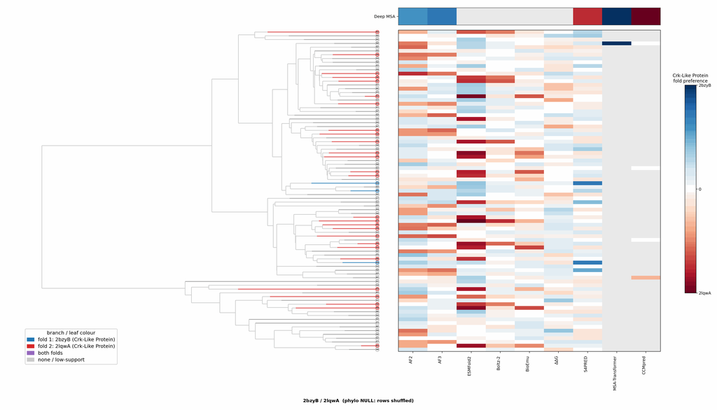

## Cluster metrics table

Per-cluster metrics underlying the figures above.

| cluster | n | neff | AF2_TM1 | AF2_TM2 | AF3_TM1 | AF3_TM2 | RE-MSAT-COM | RE-MSAT1 | RE-MSAT2 | ESM_SEQIDS | ESM_TM1 | ESM_TM2 | ΔΔG_Bias | ΔΔG_Bias_std | ΔΔG_frac_F1 | Boltz2_pref | S4PRED_pref | CCMpred_pref | BioEmu_pref |
| --- | --- | --- | --- | --- | --- | --- | --- | --- | --- | --- | --- | --- | --- | --- | --- | --- | --- | --- | --- |
| Deep | - | - | 0.71 | 0.39 | 0.74 | 0.38 | - | 0.34 | 0.32 | - | - | - | - | - | - | - | -0.12 | -0.0 | - |
| 000 | 165.0 | 29.0 | 0.28 | 0.23 | 0.56 | 0.24 | 0.0 | 0.03 | 0.01 | 001; 001; 002; 002; 005; 009; 005; 009; 010; 010 | 0.69 ± 0.01 | 0.35 ± 0.03 | 25.31 | 12.22 | 1.0 | 0.42 | -0.12 | 0.0 | 0.06 |
| 001 | 126.0 | 79.0 | 0.64 | 0.32 | 0.66 | 0.31 | - | 0.14 | 0.23 | 004; 004; 006; 006; 008; 007; 007; 008; 001; 001 | 0.65 ± 0.01 | 0.23 ± 0.03 | 30.74 | 7.96 | 1.0 | 0.38 | -0.15 | -0.0 | 0.19 |
| 002 | 102.0 | 76.0 | 0.72 | 0.27 | 0.73 | 0.32 | - | - | 0.01 | 009; 006; 009; 006; 005; 005; 004; 004; 007; 007 | 0.66 ± 0.01 | 0.28 ± 0.05 | 33.16 | 10.38 | 1.0 | 0.41 | -0.14 | 0.0 | 0.13 |
| 003 | 93.0 | 75.0 | 0.62 | 0.26 | 0.62 | 0.26 | - | - | 0.01 | 001; 002; 006; 005; 002; 001; 006; 005; 003; 003 | 0.65 ± 0.00 | 0.25 ± 0.04 | 30.36 | 13.93 | 1.0 | 0.37 | -0.14 | 0.0 | 0.22 |
| 004 | 87.0 | 31.0 | 0.63 | 0.26 | 0.75 | 0.36 | - | - | 0.34 | - | - | - | 27.21 | 10.93 | 1.0 | 0.08 | -0.16 | - | 0.04 |
| 005 | 84.0 | 31.0 | 0.33 | 0.28 | 0.43 | 0.26 | - | - | 0.0 | - | - | - | 37.0 | 8.49 | 1.0 | 0.4 | -0.13 | - | 0.11 |
| 006 | 79.0 | 44.0 | 0.31 | 0.22 | 0.28 | 0.18 | - | - | 0.01 | - | - | - | 32.41 | 12.42 | 1.0 | 0.44 | -0.16 | - | 0.1 |
| 007 | 79.0 | 6.0 | 0.6 | 0.24 | 0.74 | 0.29 | - | 0.0 | 0.01 | - | - | - | 10.78 | 6.41 | 0.9 | 0.45 | -0.16 | - | 0.11 |
| 008 | 78.0 | 45.0 | 0.71 | 0.28 | 0.75 | 0.34 | - | - | 0.02 | - | - | - | 28.36 | 4.34 | 1.0 | 0.18 | -0.15 | - | 0.08 |
| 009 | 76.0 | 39.0 | 0.3 | 0.21 | 0.34 | 0.22 | - | - | 0.17 | - | - | - | 33.6 | 12.38 | 1.0 | 0.42 | -0.06 | - | 0.14 |
| 010 | 74.0 | 46.0 | 0.63 | 0.25 | 0.75 | 0.32 | - | - | 0.0 | - | - | - | 35.63 | 11.53 | 1.0 | 0.37 | -0.15 | - | 0.1 |
| 011 | 73.0 | 11.0 | 0.58 | 0.23 | 0.64 | 0.32 | 0.0 | 0.0 | 0.01 | - | - | - | 27.58 | 7.3 | 1.0 | 0.37 | -0.15 | - | 0.28 |
| 012 | 72.0 | 50.0 | 0.52 | 0.25 | 0.63 | 0.3 | 0.0 | 0.0 | 0.01 | - | - | - | 28.3 | 11.03 | 1.0 | 0.33 | -0.16 | - | 0.08 |
| 013 | 70.0 | 34.0 | 0.28 | 0.17 | 0.32 | 0.18 | - | - | 0.02 | - | - | - | 28.61 | 11.69 | 1.0 | 0.11 | -0.15 | - | 0.09 |
| 014 | 68.0 | 27.0 | 0.76 | 0.27 | 0.71 | 0.26 | - | - | 0.03 | - | - | - | 23.34 | 6.78 | 1.0 | 0.4 | -0.03 | - | 0.11 |
| 015 | 67.0 | 48.0 | 0.7 | 0.28 | 0.72 | 0.33 | - | - | 0.26 | - | - | - | 31.64 | 15.54 | 1.0 | 0.33 | -0.12 | - | 0.36 |
| 016 | 65.0 | 50.0 | 0.72 | 0.35 | 0.74 | 0.39 | 0.0 | 0.0 | 0.01 | - | - | - | 30.1 | 12.83 | 1.0 | 0.29 | -0.16 | - | 0.17 |
| 017 | 65.0 | 12.0 | 0.32 | 0.19 | 0.38 | 0.21 | - | - | 0.01 | - | - | - | 37.28 | 6.32 | 1.0 | 0.05 | -0.12 | - | 0.09 |
| 018 | 64.0 | 47.0 | 0.72 | 0.32 | 0.75 | 0.38 | - | - | 0.04 | - | - | - | 28.12 | 8.44 | 1.0 | 0.33 | -0.15 | - | 0.21 |
| 019 | 64.0 | 41.0 | 0.7 | 0.28 | 0.73 | 0.32 | - | - | 0.04 | - | - | - | 31.03 | 11.09 | 1.0 | -0.0 | -0.16 | - | 0.14 |
| 020 | 63.0 | 22.0 | 0.69 | 0.29 | 0.73 | 0.35 | - | - | 0.01 | - | - | - | 33.69 | 5.31 | 1.0 | 0.04 | -0.11 | - | 0.1 |
| 021 | 63.0 | 20.0 | 0.43 | 0.22 | 0.64 | 0.23 | - | - | 0.0 | - | - | - | 45.76 | 6.85 | 1.0 | 0.39 | -0.13 | - | 0.19 |
| 022 | 62.0 | 62.0 | 0.7 | 0.31 | 0.8 | 0.3 | - | - | 0.0 | - | - | - | 25.92 | 7.06 | 1.0 | 0.08 | -0.07 | - | 0.09 |
| 023 | 61.0 | 21.0 | 0.23 | 0.22 | 0.27 | 0.22 | 0.0 | 0.0 | 0.01 | - | - | - | 26.55 | 12.31 | 1.0 | 0.38 | -0.15 | - | 0.1 |
| 024 | 60.0 | 50.0 | 0.64 | 0.32 | 0.73 | 0.34 | - | - | 0.02 | - | - | - | 33.42 | 11.41 | 1.0 | 0.1 | -0.16 | - | 0.04 |
| 025 | 60.0 | 3.0 | 0.62 | 0.24 | 0.69 | 0.25 | - | 0.0 | 0.01 | - | - | - | 11.16 | 9.74 | 1.0 | 0.45 | -0.14 | - | 0.1 |
| 026 | 59.0 | 41.0 | 0.72 | 0.28 | 0.71 | 0.34 | 0.0 | 0.0 | 0.03 | - | - | - | 31.21 | 10.92 | 1.0 | 0.11 | -0.12 | - | 0.09 |
| 027 | 58.0 | 26.0 | 0.71 | 0.34 | 0.73 | 0.35 | - | 0.33 | 0.3 | - | - | - | 33.27 | 7.71 | 1.0 | -0.04 | -0.14 | - | 0.09 |
| 028 | 55.0 | 12.0 | 0.32 | 0.22 | 0.34 | 0.18 | - | - | 0.01 | - | - | - | 36.03 | 5.16 | 1.0 | 0.16 | -0.13 | - | 0.06 |

[output cut: 56 more lines]